# NewGlobe Case Study - Analyst M&E/Data Analytics Teams

Kamran Ahmed

2023-10-17

Load libraries

```r
library(tidyverse)
library(readxl)
```

# Load Data

```r
Lesson_completion <- read_excel("Lesson completion.xlsx")
View(Lesson_completion)
```

```r
Pupil_attendance <- read_excel("Pupil attendance.xlsx")
View(Pupil_attendance)
```

```r
Pupil_scores <- read_excel("Pupil scores.xlsx")
View(Pupil_scores)
```

```r
School_information <- read_excel("School_information.xlsx")
View(School_information)
```

# Step 1: Data cleaning

```r
# Create a base file by reshaping the “Pupil scores” file
Pupil_scores <- Pupil_scores %>%
  pivot_wider(names_from = subject, values_from = score)
```

```r
# Merge Pupil_attendance file to the base file i.e, Pupil_scores file
pupil_df <- merge(Pupil_scores, Pupil_attendance, by = c("pupil_id", "school_id", "grade"))
View(pupil_df)
```

```r
# Merge teacher's data
pupil_teacher_df <- merge(pupil_df, Lesson_completion, by = c("school_id", "grade"))
View(pupil_teacher_df)
```

```r
#merge school information
pupil_teacher_school_df <- merge(pupil_teacher_df, School_information, by = "school_id")
View(pupil_teacher_school_df)
```

# Step 2: Calculating KPIs

```r
network_level_average_kpi <- round(sum(pupil_teacher_school_df$present_records)/sum(pupil_teacher_school_df$attendance_records), 2)
network_level_average_kpi
```

```
## [1] 0.76
```

```r
school_level_average_kpi <- pupil_teacher_school_df %>%
  select(school_id, present_records, attendance_records) %>%
  group_by(school_id) %>%
  summarise(total_present = sum(present_records), total_records = sum(attendance_records)) %>%
  mutate(school_kpi = round(total_present/total_records, 2)) %>%
  summarise(round(mean(school_kpi), 2))
school_level_average_kpi
```

```
## # A tibble: 1 × 1
##   `round(mean(school_kpi), 2)`
##                          <dbl>
## 1                         0.76
```

# Step 3: Descriptives

Please create a figure or a table, whichever you prefer, which shows average fluency scores for each of the five grades.

```r
pupil_teacher_school_df %>%
  select(grade, Fluency) %>%
  group_by(grade) %>%
  summarise(mean(Fluency, na.rm = TRUE))
```

```
## # A tibble: 5 × 2
##   grade   `mean(Fluency, na.rm = TRUE)`
##   <chr>                           <dbl>
## 1 Grade 1                          53.1
## 2 Grade 2                         104.
## 3 Grade 3                         127.
## 4 Grade 4                         145.
## 5 Grade 5                         155.
```

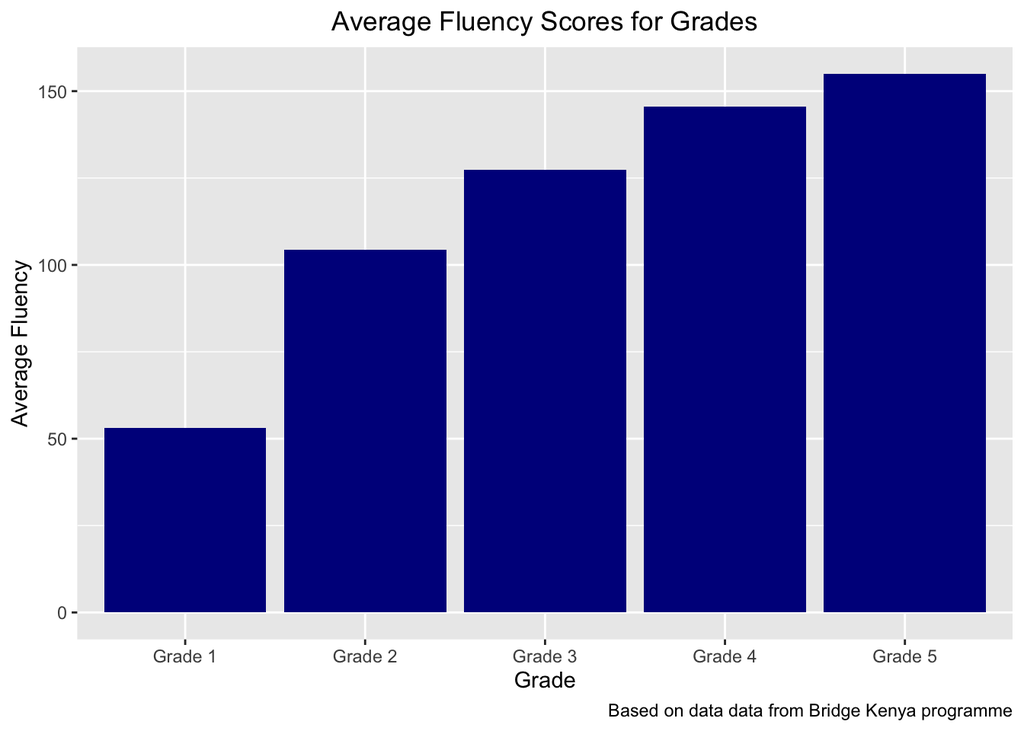

```r
pupil_teacher_school_df %>%
  select(grade, Fluency) %>%
  group_by(grade) %>%
  summarise(avg_fluency = mean(Fluency, na.rm = TRUE)) %>%
  ggplot(aes(x = grade, y=avg_fluency))+
  geom_col(fill= "dark blue")+
  labs(title = "Average Fluency Scores for Grades",
       x = "Grade",
       y = "Average Fluency",
       caption = "Based on data data from Bridge Kenya programme")+
  theme(plot.title = element_text(hjust = 0.5))
```

● Which regions (using the “region” variable) have the lowest and highest average fluency score across all grades?

```r
pupil_teacher_school_df %>%
  select(region, Fluency) %>%
  group_by(region) %>%
  summarise(avg_fluency = mean(Fluency, na.rm = TRUE)) %>%
  filter(avg_fluency == max(avg_fluency, na.rm=TRUE) | avg_fluency == min(avg_fluency, na.rm=TRUE))
```

```
## # A tibble: 2 × 2
##   region    avg_fluency
##   <chr>           <dbl>
## 1 Kirinyaga        60.3
## 2 Machakos        158.
```

● Please create a binary variable that is 1 if a given child reads at 10 or lower, and 0 otherwise. Please create a bar chart with grades on the x-axis, and the share of pupils scoring under this threshold for each grade.

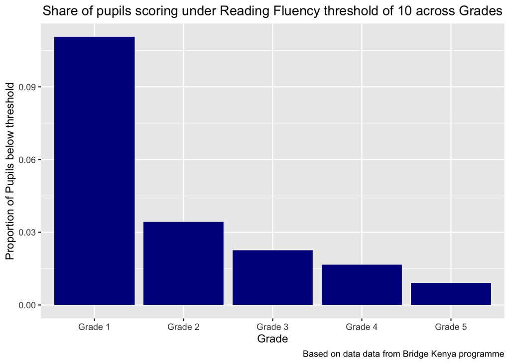

```r
pupil_teacher_school_df$not_fluent <- ifelse(pupil_teacher_school_df$Fluency <=10, 1, 0)

pupil_teacher_school_df %>%
  select(grade, not_fluent) %>%
  group_by(grade) %>%
  summarise(proportion_not_fluent = mean(not_fluent, na.rm = TRUE)) %>%
  ggplot(aes(x = grade, y=proportion_not_fluent))+
  geom_col(fill= "dark blue")+
  labs(title = "Share of pupils scoring under Reading Fluency threshold of 10 across Grades",
       x = "Grade",
       y = "Proportion of Pupils below threshold",
       caption = "Based on data data from Bridge Kenya programme")+
  theme(plot.title = element_text(hjust = 0.5))
```

● What school has the highest share of pupils scoring under this threshold in grade 3?

```r
pupil_teacher_school_df %>%
  filter(grade == "Grade 3") %>%
  select(school_id, not_fluent) %>%
  group_by(school_id) %>%
  summarise(proportion_not_fluent = mean(not_fluent, na.rm = TRUE)) %>%
  filter(proportion_not_fluent == max(proportion_not_fluent, na.rm=TRUE))
```

```
## # A tibble: 1 × 2
##   school_id proportion_not_fluent
##       <dbl>                 <dbl>
## 1    223941                 0.342
```

# Step 4: Impact evaluation

During this term, we rolled out an intensive after-school tutoring program in 55 schools. The selection to be a part of the 55 schools was randomly assigned - in other words, these schools were part of a randomized controlled trial (RCT). The “School Information” data set has a binary variable for whether each school was part of the program or not.

● Our Chief Academic Officer would like to know whether this program had any effects on test scores in math, Kiswahili, fluency, and/or student attendance. Please conduct any calculations you see fit to answer his questions.

```r
summary(lm(Math ~ tutoring_program, data = pupil_teacher_school_df))
```

```
##
## Call:
## lm(formula = Math ~ tutoring_program, data = pupil_teacher_school_df)
##
## Residuals:
##      Min       1Q   Median       3Q      Max
## -0.74010 -0.14375  0.02735  0.19402  0.29402
##
## Coefficients:
##                     Estimate Std. Error t value Pr(>|t|)
## (Intercept)         0.705982   0.002852  247.56   <2e-16 ***
## tutoring_programYes 0.037767   0.004026    9.38   <2e-16 ***
## ---
## Signif. codes:  0 '***' 0.001 '**' 0.01 '*' 0.05 '.' 0.1 ' ' 1
##
## Residual standard error: 0.2213 on 12085 degrees of freedom
##   (614 observations deleted due to missingness)
## Multiple R-squared:  0.007227,   Adjusted R-squared:  0.007145
## F-statistic: 87.98 on 1 and 12085 DF,  p-value: < 2.2e-16
```

```r
summary(lm(Kiswahili ~ tutoring_program, data = pupil_teacher_school_df))
```

```
##
## Call:
## lm(formula = Kiswahili ~ tutoring_program, data = pupil_teacher_school_df)
##
## Residuals:
##      Min       1Q   Median       3Q      Max
## -0.80660 -0.12948  0.06338  0.19340  0.32052
##
## Coefficients:
##                     Estimate Std. Error t value Pr(>|t|)
## (Intercept)         0.679482   0.002923   232.4   <2e-16 ***
## tutoring_programYes 0.127121   0.004127    30.8   <2e-16 ***
## ---
## Signif. codes:  0 '***' 0.001 '**' 0.01 '*' 0.05 '.' 0.1 ' ' 1
##
## Residual standard error: 0.227 on 12099 degrees of freedom
##   (600 observations deleted due to missingness)
## Multiple R-squared:  0.07272,    Adjusted R-squared:  0.07264
## F-statistic: 948.8 on 1 and 12099 DF,  p-value: < 2.2e-16
```

```r
summary(lm(Fluency ~ tutoring_program, data = pupil_teacher_school_df))
```

```
##
## Call:
## lm(formula = Fluency ~ tutoring_program, data = pupil_teacher_school_df)
##
## Residuals:
##     Min      1Q  Median      3Q     Max
## -130.01  -56.02  -12.02   49.98  252.99
##
## Coefficients:
##                     Estimate Std. Error t value Pr(>|t|)
## (Intercept)          97.2551     0.9118  106.66   <2e-16 ***
## tutoring_programYes  32.7602     1.2810   25.57   <2e-16 ***
## ---
## Signif. codes:  0 '***' 0.001 '**' 0.01 '*' 0.05 '.' 0.1 ' ' 1
##
## Residual standard error: 70.09 on 11974 degrees of freedom
##   (725 observations deleted due to missingness)
## Multiple R-squared:  0.05179,    Adjusted R-squared:  0.05171
## F-statistic:   654 on 1 and 11974 DF,  p-value: < 2.2e-16
```

```r
pupil_teacher_school_df$student_attendance_score <- pupil_teacher_school_df$present_records/pupil_teacher_school_df$attendance_records

summary(lm(student_attendance_score ~ tutoring_program, data = pupil_teacher_school_df))
```

```
##
## Call:
## lm(formula = student_attendance_score ~ tutoring_program, data = pupil_teacher_school_df)
##
## Residuals:
##      Min       1Q   Median       3Q      Max
## -0.77166 -0.08931  0.03993  0.13030  0.25300
##
## Coefficients:
##                     Estimate Std. Error t value Pr(>|t|)
## (Intercept)         0.747002   0.002232 334.613  < 2e-16 ***
## tutoring_programYes 0.024660   0.003159   7.806 6.35e-15 ***
## ---
## Signif. codes:  0 '***' 0.001 '**' 0.01 '*' 0.05 '.' 0.1 ' ' 1
##
## Residual standard error: 0.178 on 12699 degrees of freedom
## Multiple R-squared:  0.004776,   Adjusted R-squared:  0.004697
## F-statistic: 60.94 on 1 and 12699 DF,  p-value: 6.348e-15
```

● After conducting the impact evaluation, we have heard anecdotally that teachers in schools that received tutoring felt more motivated and were completing their lessons at a faster pace. Hence, we could worry that the effects that we see are not (solely) due to the tutoring program, but also due to the higher lesson completion rate. Does this hypothesis hold up in the data?

```r
summary(lm(Math ~ tutoring_program+lesson_completion_rate, data = pupil_teacher_school_df))
```

```
##
## Call:
## lm(formula = Math ~ tutoring_program + lesson_completion_rate,
##     data = pupil_teacher_school_df)
##
## Residuals:
##      Min       1Q   Median       3Q      Max
## -0.76050 -0.14325  0.02933  0.19017  0.36814
##
## Coefficients:
##                        Estimate Std. Error t value Pr(>|t|)
## (Intercept)            0.631402   0.006098 103.548   <2e-16 ***
## tutoring_programYes    0.037331   0.003995   9.344   <2e-16 ***
## lesson_completion_rate 0.122980   0.008907  13.807   <2e-16 ***
## ---
## Signif. codes:  0 '***' 0.001 '**' 0.01 '*' 0.05 '.' 0.1 ' ' 1
##
## Residual standard error: 0.2196 on 12084 degrees of freedom
##   (614 observations deleted due to missingness)
## Multiple R-squared:  0.02265,    Adjusted R-squared:  0.02249
## F-statistic:   140 on 2 and 12084 DF,  p-value: < 2.2e-16
```

```r
summary(lm(Kiswahili ~ tutoring_program+lesson_completion_rate, data = pupil_teacher_school_df))
```

```
##
## Call:
## lm(formula = Kiswahili ~ tutoring_program + lesson_completion_rate,
##     data = pupil_teacher_school_df)
##
## Residuals:
##     Min      1Q  Median      3Q     Max
## -0.8188 -0.1275  0.0612  0.1844  0.3505
##
## Coefficients:
##                        Estimate Std. Error t value Pr(>|t|)
## (Intercept)            0.649533   0.006293 103.216  < 2e-16 ***
## tutoring_programYes    0.126939   0.004122  30.793  < 2e-16 ***
## lesson_completion_rate 0.049367   0.009189   5.372 7.92e-08 ***
## ---
## Signif. codes:  0 '***' 0.001 '**' 0.01 '*' 0.05 '.' 0.1 ' ' 1
##
## Residual standard error: 0.2267 on 12098 degrees of freedom
##   (600 observations deleted due to missingness)
## Multiple R-squared:  0.07492,    Adjusted R-squared:  0.07477
## F-statistic: 489.9 on 2 and 12098 DF,  p-value: < 2.2e-16
```

```r
summary(lm(Fluency ~ tutoring_program+lesson_completion_rate, data = pupil_teacher_school_df))
```

```
##
## Call:
## lm(formula = Fluency ~ tutoring_program + lesson_completion_rate,
##     data = pupil_teacher_school_df)
##
## Residuals:
##     Min      1Q  Median      3Q     Max
## -148.52  -55.43  -10.80   49.43  240.96
##
## Coefficients:
##                        Estimate Std. Error t value Pr(>|t|)
## (Intercept)             115.759      1.954   59.25   <2e-16 ***
## tutoring_programYes      32.763      1.275   25.70   <2e-16 ***
## lesson_completion_rate  -30.357      2.839  -10.70   <2e-16 ***
## ---
## Signif. codes:  0 '***' 0.001 '**' 0.01 '*' 0.05 '.' 0.1 ' ' 1
##
## Residual standard error: 69.76 on 11973 degrees of freedom
##   (725 observations deleted due to missingness)
## Multiple R-squared:  0.06076,    Adjusted R-squared:  0.06061
## F-statistic: 387.3 on 2 and 11973 DF,  p-value: < 2.2e-16
```

```r
summary(lm(student_attendance_score ~ tutoring_program+lesson_completion_rate, data = pupil_teacher_school_df))
```

```
##
## Call:
## lm(formula = student_attendance_score ~ tutoring_program + lesson_completion_rate,
##     data = pupil_teacher_school_df)
##
## Residuals:
##      Min       1Q   Median       3Q      Max
## -0.77481 -0.08920  0.04001  0.12993  0.26241
##
## Coefficients:
##                        Estimate Std. Error t value Pr(>|t|)
## (Intercept)            0.737594   0.004808 153.409  < 2e-16 ***
## tutoring_programYes    0.024591   0.003159   7.785 7.49e-15 ***
## lesson_completion_rate 0.015573   0.007049   2.209   0.0272 *
## ---
## Signif. codes:  0 '***' 0.001 '**' 0.01 '*' 0.05 '.' 0.1 ' ' 1
##
## Residual standard error: 0.178 on 12698 degrees of freedom
## Multiple R-squared:  0.005158,   Adjusted R-squared:  0.005001
## F-statistic: 32.92 on 2 and 12698 DF,  p-value: 5.501e-15
```